# Machine Learning - Random Forest

Carmen Rodriguez Cabrera

11/29/2021

## Predicting Recipe Popularity

```r
#LOAD DATASET
recipesdat<-read.csv(file = "recipes_final.csv")
#str(recipesdat) # 1142 recipes
```

### Distributions of outcome

Initially we were interested in predicting rating, however, the distribution of ratings was left skewed as most recipes are highly rated with 4 or 5 stars (median = 4.98). This is simply because people who follow food blogs enjoy the recipes and so they are likely to rate them highly. Therefore, we decided to predict recipe popularity defined as the number of ratings `n_ratings` using recipe features as the predictors.

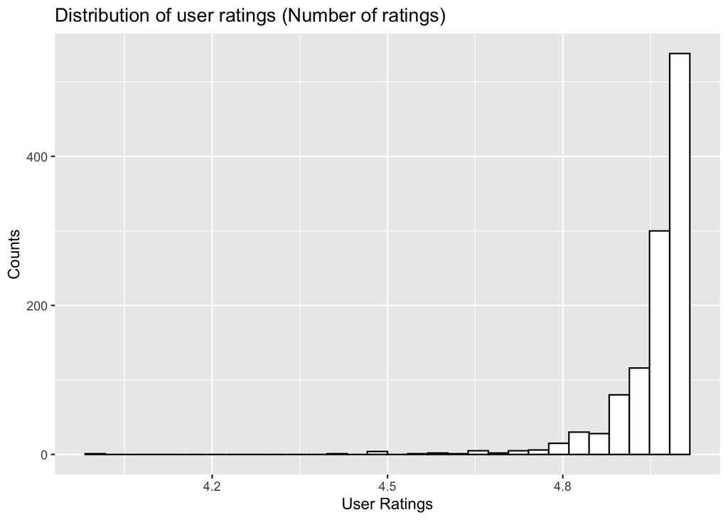

```r
recipesdat %>% ggplot(aes(x = rating)) + geom_histogram(color = "black", fill = "white") + labs( x = "User Ratings", y= "Counts", title = "Distribution of user ratings (Number of ratings)")
```

```r
# left skewed distribution- most recipes are highly rated --
```

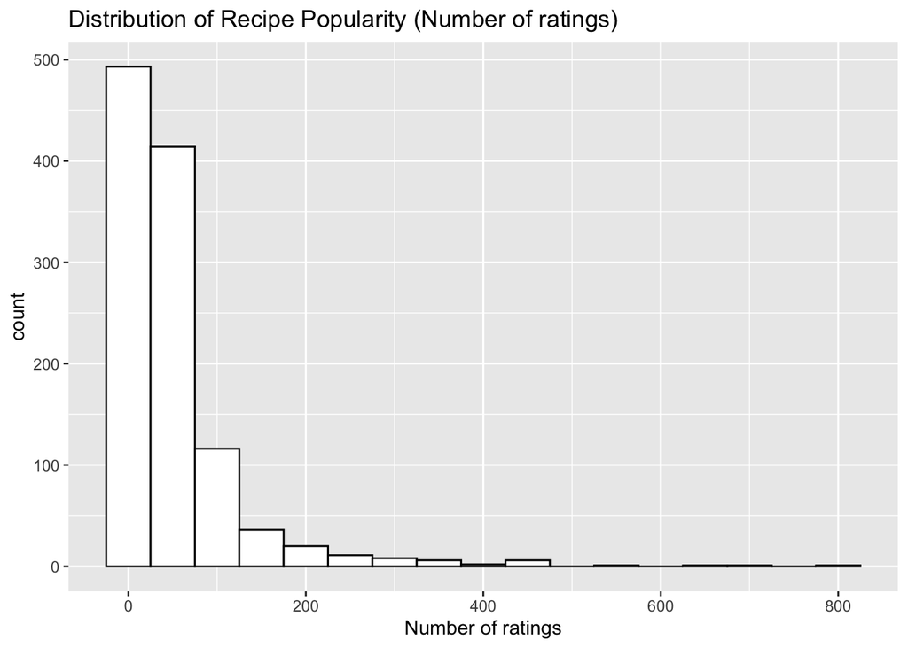

```r
#Remove missing and recipe with 2031
recipesdat<-recipesdat %>% filter(n_ratings != 2031) %>% drop_na(n_ratings) #1116
dist<-recipesdat %>% ggplot(aes(x = n_ratings)) + geom_histogram(color = "black", fill = "white", binwidth = 50) + labs( x = "Number of ratings", title = "Distribution of Recipe Popularity (Number of ratings)")

dist
```

```r
# ggsave("dist.png", limitsize = TRUE)

png("dist.png", width = 400, height = 400)
dist
dev.off()
```

### Partition data

We use `createDataPartition` to split the data into equally-sized training and test sets.

```r
set.seed(123)
recipes_index_train = createDataPartition(y = recipesdat$n_ratings,
                                  times = 1, p = 0.5, list = FALSE)
recipes_train = slice(recipesdat, recipes_index_train)
recipes_test = slice(recipesdat, -recipes_index_train)
```

### Exploratory Analysis

Using the training set we make some plots to help assess the relationship between recipe popularity `n_ratings`, and each of the other features of interest in the data set.

Looking at the scatterplots below we do not see any patterns between recipe popularity and any features. This was further confirmed using a correlation matrix, where we can see that none of the features are highly correlated with recipe popularity `n_ratings`.

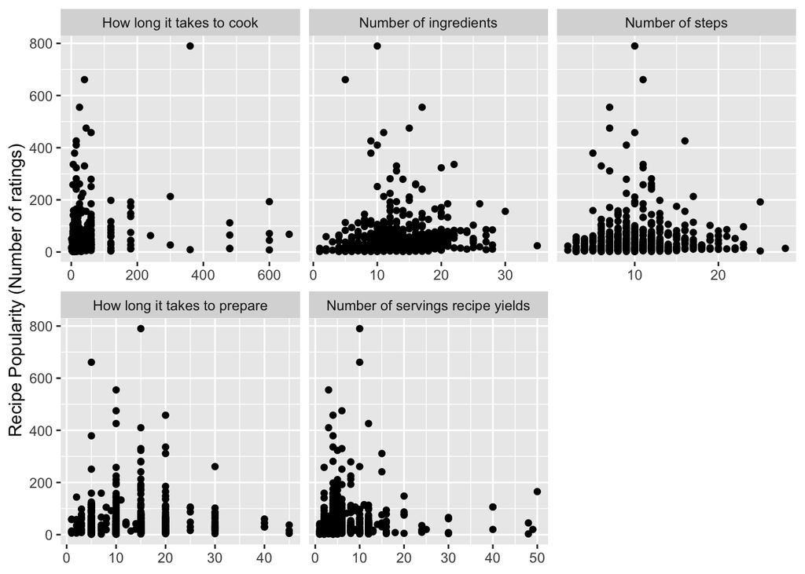

```r
scatter<-recipes_train%>%
  gather(predictor, value, c(cook_time, prep_time, servings, n_ingredients, n_steps)) %>%
  ggplot(aes(x = value, y = n_ratings)) +
  geom_point() +
  facet_wrap(~ predictor, scales = 'free_x',
             labeller =
               as_labeller(c("cook_time" = "How long it takes to cook",
                             "prep_time" = "How long it takes to prepare",
                             "servings" = "Number of servings recipe yields",
                            "n_ingredients" = "Number of ingredients",
                              "n_steps" = "Number of steps"))) +
  xlab(NULL) + ylab("Recipe Popularity (Number of ratings)")

scatter
```

```r
#ggsave("scatter.png", limitsize = TRUE)

png("scatter.png", width = 600, height = 400)
scatter
dev.off()
```

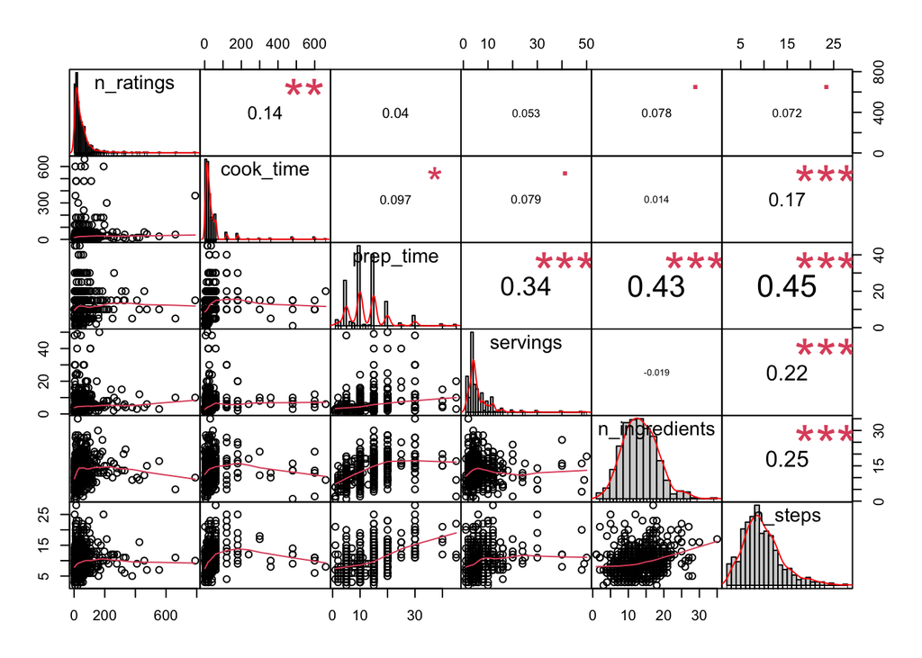

```r
my_data <-recipes_train %>% dplyr::select(n_ratings,cook_time, prep_time, servings, n_ingredients, n_steps)
chart.Correlation(my_data, histogram=TRUE, pch=19,)
```

```r
png("corr.png", width = 600, height = 600)
chart.Correlation(my_data, histogram=TRUE, pch=19,)
#png("corr.png", width = 400, height = 400)
dev.off()
```

### Preliminary assessment - fit a linear regression model

```r
#Preliminary- no correlation between features of interest and recipe popularity (number of ratings)
fit_lm<-lm(n_ratings ~  cook_time + prep_time + n_ingredients + servings +
                           n_steps, data = recipes_train)

summary(fit_lm)
```

```
##
## Call:
## lm(formula = n_ratings ~ cook_time + prep_time + n_ingredients +
##     servings + n_steps, data = recipes_train)
##
## Residuals:
##     Min      1Q  Median      3Q     Max
## -112.34  -37.92  -21.80    8.16  691.21
##
## Coefficients:
##               Estimate Std. Error t value Pr(>|t|)
## (Intercept)   39.94999   12.67041   3.153  0.00172 **
## cook_time      0.13949    0.04447   3.137  0.00181 **
## prep_time     -0.41242    0.64848  -0.636  0.52508
## n_ingredients  1.12231    0.76867   1.460  0.14491
## servings       0.76723    0.64292   1.193  0.23331
## n_steps       -0.40844    1.03153  -0.396  0.69231
## ---
## Signif. codes:  0 '***' 0.001 '**' 0.01 '*' 0.05 '.' 0.1 ' ' 1
##
## Residual standard error: 79.56 on 488 degrees of freedom
##   (64 observations deleted due to missingness)
## Multiple R-squared:  0.02614,    Adjusted R-squared:  0.01616
## F-statistic:  2.62 on 5 and 488 DF,  p-value: 0.02371
```

Only `cook_time` is significantly associated with recipe popularity. More specifically, recipes with higher cook time have slightly higher number of ratings.

### Random Forest

In this section:

We conducted Random Forest regression to predict recipe popularity (number of ratings) of the recipe based on other features.

1. Plotted the full model to illustrate the error rate as we average across more trees. This showed that our error rate stabilized with around 200 trees but continues to decrease slowly until around 300 or so trees.

```r
set.seed(123)
# Random forest
#First we fit a model with all predictors of interest
popularity<-randomForest(n_ratings ~  cook_time + prep_time + n_ingredients + servings +
                           n_steps, mtry = 5, na.action = na.exclude, data = recipes_train)

popularity  # Does not perform well -- there is barely any corr between outcome and predictors
```

```
##
## Call:
##  randomForest(formula = n_ratings ~ cook_time + prep_time + n_ingredients +      servings + n_steps, data = recipes_train, mtry = 5, na.action = na.exclude)
##                Type of random forest: regression
##                      Number of trees: 500
## No. of variables tried at each split: 5
##
##           Mean of squared residuals: 7949.372
##                     % Var explained: -23.8
```

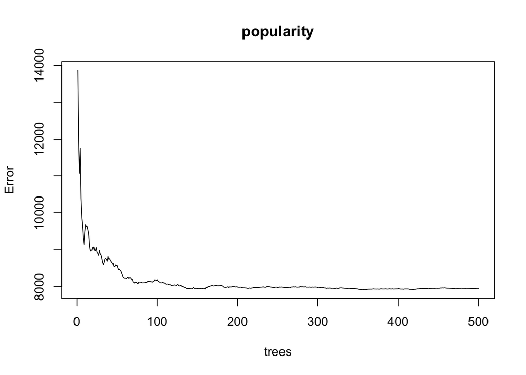

```r
#Plotting the model will illustrate the error rate as we average across more trees and shows that our error rate stabilizes with around 200 trees but continues to decrease slowly until around 300 or so trees.
plot(popularity)
```

2. Re-ran the model with 200 trees.

```r
#Re-run model with only 200 trees
popularity1<-randomForest(n_ratings ~  cook_time + prep_time + n_ingredients + servings +
                           n_steps, mtry = 5, ntree = 200, na.action = na.exclude, data = recipes_train)
```

3. Assessed performance in the test set

The mean square error for the prediction model is 6098.

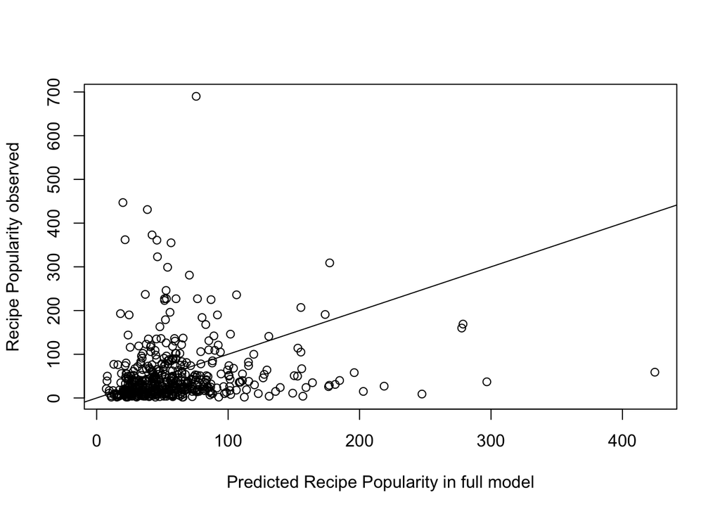

```r
#How well does it perform on the test set?
prediction_fullmodel<- predict(popularity1, newdata = recipes_train)

plot(prediction_fullmodel, recipes_test$n_ratings, ylab =  "Recipe Popularity observed", xlab = "Predicted Recipe Popularity in full model") #that's not very good
abline(0,1)
```

```r
mean((prediction_fullmodel - recipes_test$n_ratings)^2, na.rm = TRUE)
```

```
## [1] 6098.878
```

```r
# png("fit.png")
# print(fit)
# dev.off()
```

4. Examined which features are the best predictors through variable importance analysis.

We calculated the mean decrease Gini which is a measure of variable importance based on the Gini impurity index used for the calculation of splits in trees. The variables are presented from descending importance.

```r
# Variable importance
variable_importance <- importance(popularity1)
varI_table <- data_frame(Feature = rownames(variable_importance),
                  Gini = variable_importance[,1]) %>%
                  arrange(desc(Gini))
varI_table
```

```
## # A tibble: 5 × 2
##   Feature          Gini
##   <chr>           <dbl>
## 1 cook_time     681521.
## 2 n_ingredients 602495.
## 3 servings      487071.
## 4 n_steps       476441.
## 5 prep_time     280326.
```

5. Re-fitting the model with only high importance variables- Reduced model

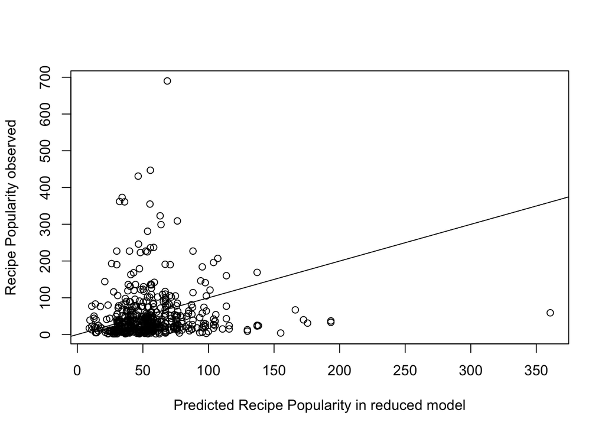

```r
#Re-run model with only 200 trees
popularity2<-randomForest(n_ratings ~  cook_time  + n_ingredients, ntree = 200, na.action = na.exclude, data = recipes_train)

#How well does it perform on the test set?
prediction_reduced<- predict(popularity2, newdata = recipes_train)

plot(prediction_reduced, recipes_test$n_ratings, ylab =  "Recipe Popularity observed", xlab = "Predicted Recipe Popularity in reduced model") #that's not very good
abline(0,1)
```

```r
mean((prediction_reduced - recipes_test$n_ratings)^2, na.rm = TRUE)
```

```
## [1] 5581.675
```

### References

- http://developmentaldatascience.org/post/29-01-18_metaforest_no_effect/
- https://uc-r.github.io/random_forests
- https://stats.stackexchange.com/questions/447863/log-transforming-target-var-for-training-a-random-forest-regressor